# R Notebook

y = m1x1 + m2x2 = c instead of y = mx + c i.e. allow for multiple predictors (X).

### the data

```r
library(tidyverse)
library(janitor)
library(mosaicData)
```

|  | hightemp | lowtemp | avgtemp | spring | summer | fall | cloudcover | precip | volume | weekday | dayType |
| --- | --- | --- | --- | --- | --- | --- | --- | --- | --- | --- | --- |
| 1 | 83 | 50 | 66.5 | 0 | 1 | 0 | 7.6 | 0.00 | 501 | TRUE | weekday |
| 2 | 73 | 49 | 61.0 | 0 | 1 | 0 | 6.3 | 0.29 | 419 | TRUE | weekday |
| 3 | 74 | 52 | 63.0 | 1 | 0 | 0 | 7.5 | 0.32 | 397 | TRUE | weekday |
| 4 | 95 | 61 | 78.0 | 0 | 1 | 0 | 2.6 | 0.00 | 385 | FALSE | weekend |
| 5 | 44 | 52 | 48.0 | 1 | 0 | 0 | 10.0 | 0.14 | 200 | TRUE | weekday |
| 6 | 69 | 54 | 61.5 | 1 | 0 | 0 | 6.6 | 0.02 | 375 | TRUE | weekday |

Can we explain the variation in `volume` using other predictors?

potential predictors: -temp (fahrenheit) -season -cloudcover (0-10) -precipitation (inches) -weekday

issues with data in raw form: -spring to fall are numbers rather than logical -some collinear predictors (3 temp predictors & 2 for weekday & all seasons (remove 1)) - we want all predictors to be independent

###variable engineering -drop collinear columns -convert column types -clean names

| avgtemp | spring | summer | cloudcover | precip | volume | weekday |
| --- | --- | --- | --- | --- | --- | --- |
| 66.5 | FALSE | TRUE | 7.6 | 0.00 | 501 | TRUE |
| 61.0 | FALSE | TRUE | 6.3 | 0.29 | 419 | TRUE |
| 63.0 | TRUE | FALSE | 7.5 | 0.32 | 397 | TRUE |
| 78.0 | FALSE | TRUE | 2.6 | 0.00 | 385 | FALSE |
| 48.0 | TRUE | FALSE | 10.0 | 0.14 | 200 | TRUE |
| 61.5 | TRUE | FALSE | 6.6 | 0.02 | 375 | TRUE |
| 52.5 | TRUE | FALSE | 2.4 | 0.00 | 417 | TRUE |
| 52.0 | TRUE | FALSE | 0.0 | 0.00 | 629 | FALSE |
| 67.5 | FALSE | TRUE | 3.8 | 0.00 | 533 | FALSE |
| 62.0 | FALSE | TRUE | 4.1 | 0.00 | 547 | TRUE |

[output cut: 80 more lines]

###detect perfect collinearity (column aliases)

```r
alias(volume ~ ., RailTrail)
```

```
Model :
volume ~ hightemp + lowtemp + avgtemp + spring + summer + fall +
    cloudcover + precip + weekday + dayType

Complete :
               (Intercept) hightemp lowtemp spring summer cloudcover precip
avgtemp          0         1/2      1/2       0      0      0          0
fall             1           0        0      -1     -1      0          0
dayTypeweekend   1           0        0       0      0      0          0
               weekdayTRUE
avgtemp          0
fall             0
dayTypeweekend  -1
```

```r
alias(volume ~ ., railtrail_trim)
```

```
Model :
volume ~ avgtemp + spring + summer + cloudcover + precip + weekday
```

###simple linear regression

[output not shown]

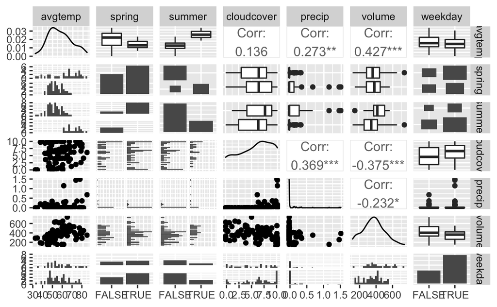

```r
ggpairs(railtrail_trim)
```

plots every variable against eachother - correlations (high) - distributions (boxplots to be different for categoric variables) - scattter plots (any discernable pattern)

Avg temp has highest correlation - start with that y = intercept + m_avg_temp * avg_temp

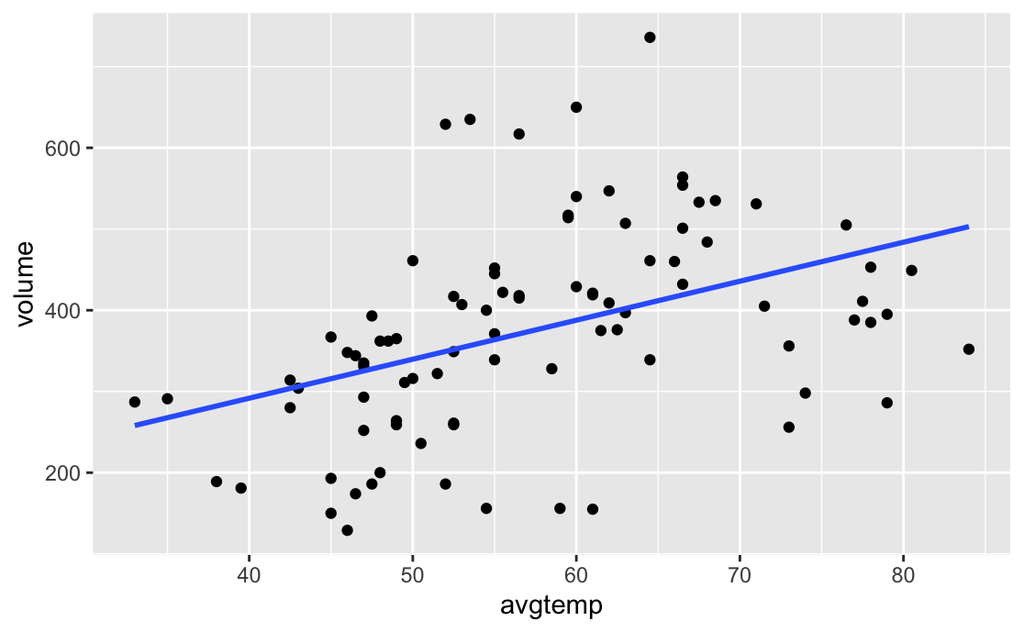

```r
railtrail_trim %>%
  ggplot(aes(avgtemp, volume))+
  geom_point()+
  geom_smooth(method = "lm", se = FALSE)
```

appears to be a linear relationship between volume and avg temperature

###goodness of fit measures

- r^2: coefficient of determination (1 = perfect)
- standard error of residuals (difference between fitted values and measured values)

```r
model
```

```
Call:
lm(formula = volume ~ avgtemp, data = railtrail_trim)

Coefficients:
(Intercept)      avgtemp
     99.602        4.802
```

```r
summary(model)
```

```
Call:
lm(formula = volume ~ avgtemp, data = railtrail_trim)

Residuals:
    Min      1Q  Median      3Q     Max
-237.53  -80.00    8.49   55.14  326.67

Coefficients:
            Estimate Std. Error t value Pr(>|t|)
(Intercept)   99.602     63.474   1.569     0.12
avgtemp        4.802      1.084   4.428 2.72e-05 ***
---
Signif. codes:  0 ‘***’ 0.001 ‘**’ 0.01 ‘*’ 0.05 ‘.’ 0.1 ‘ ’ 1

Residual standard error: 115.9 on 88 degrees of freedom
Multiple R-squared:  0.1822,    Adjusted R-squared:  0.1729
F-statistic: 19.61 on 1 and 88 DF,  p-value: 2.723e-05
```

###diagnostic plots

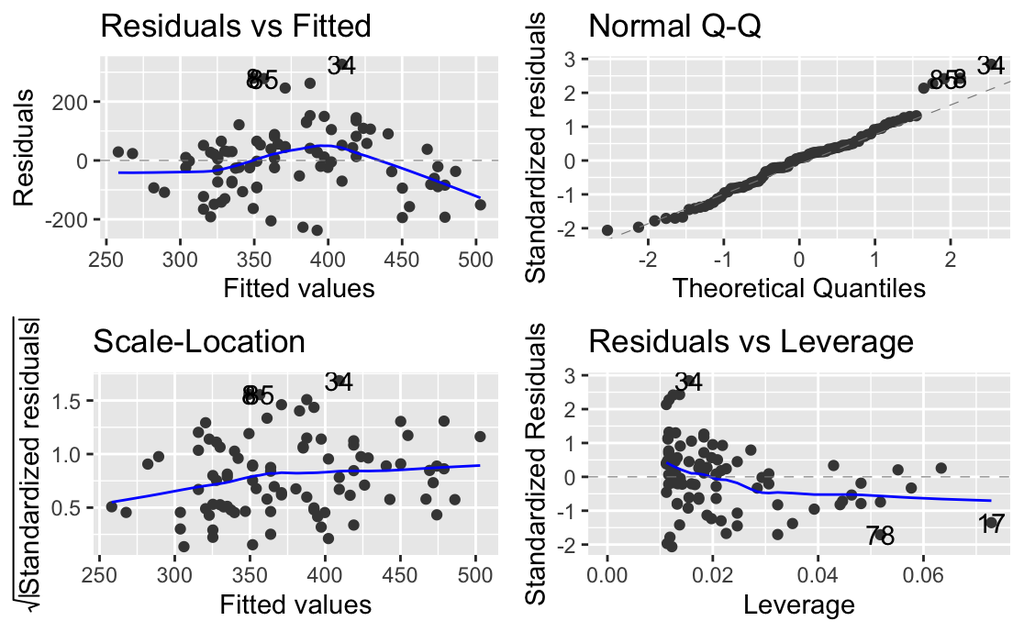

these diagnostics are fine

0.18 (r^2) of the variation in volume is explained by avg temperature & residual standard error is high (over 100 out of 500)

add predictors to improve the model - weekday

###adding a categorical predictor

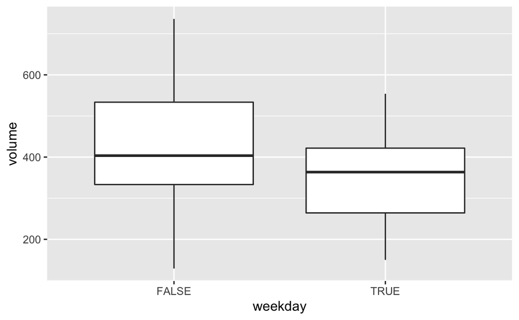

weekday appears to have an effect

| cor |
| --- |
| -0.2932675 |

-0.3 is evidence that weekday and volume are related

y = intercept + (m_avg_temp * avgtemp) + (m_weekday * weekday)

```r
model_temp_weekday
```

```
Call:
lm(formula = formula, data = railtrail_trim)

Coefficients:
(Intercept)      avgtemp  weekdayTRUE
    163.022        4.541      -70.320
```

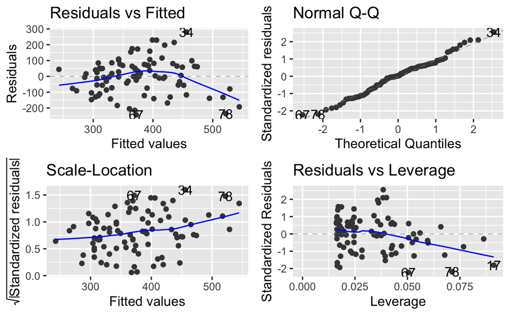

```r
summary(model_temp_weekday)
```

```
Call:
lm(formula = formula, data = railtrail_trim)

Residuals:
    Min      1Q  Median      3Q     Max
-242.92  -75.72    3.15   66.90  280.06

Coefficients:
            Estimate Std. Error t value Pr(>|t|)
(Intercept)  163.022     65.428   2.492  0.01461 *
avgtemp        4.541      1.050   4.323 4.08e-05 ***
weekdayTRUE  -70.320     25.566  -2.751  0.00724 **
---
Signif. codes:  0 ‘***’ 0.001 ‘**’ 0.01 ‘*’ 0.05 ‘.’ 0.1 ‘ ’ 1

Residual standard error: 111.8 on 87 degrees of freedom
Multiple R-squared:  0.2476,    Adjusted R-squared:  0.2303
F-statistic: 14.32 on 2 and 87 DF,  p-value: 4.214e-06
```

r^2 has improved to 0.2476 standard error has reduced (111.8)

on average there were 70 fewer people on the trails on weekdays compared to weekends holding temp constant (weekdayTRUE coefficient = -70.320)

```r
library(mosaic)
```

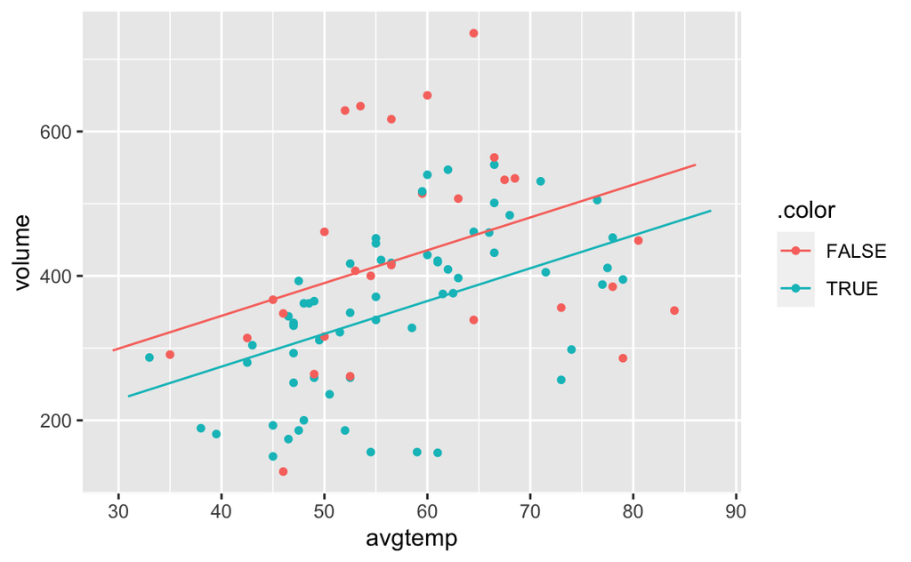

```r
model_temp_weekday <- lm(volume ~ avgtemp + weekday, railtrail_trim)
plotModel(model_temp_weekday)
```

parallel lines denoting weekdays and weekends (TRUE and FALSE)

volume = intercept + (m_avg_temp * avg_temp) + (m_weekday * weekday)

when weekday is FALSE

volume = intercept + (m_avg_temp * avg_temp) + 0

### add summer to model?

```r
model_temp_weekday_summer <- lm(volume ~ avgtemp + weekday + summer, railtrail_trim)
autoplot(model_temp_weekday_summer)
```

[output not shown]

```r
summary(model_temp_weekday_summer)
```

```
Call:
lm(formula = volume ~ avgtemp + weekday + summer, data = railtrail_trim)

Residuals:
     Min       1Q   Median       3Q      Max
-236.165  -75.448    6.184   68.496  252.680

Coefficients:
            Estimate Std. Error t value Pr(>|t|)
(Intercept)   71.376     90.336   0.790 0.431630
avgtemp        6.387      1.639   3.898 0.000192 ***
weekdayTRUE  -66.958     25.505  -2.625 0.010244 *
summerTRUE   -59.977     41.052  -1.461 0.147662
---
Signif. codes:  0 ‘***’ 0.001 ‘**’ 0.01 ‘*’ 0.05 ‘.’ 0.1 ‘ ’ 1

Residual standard error: 111.1 on 86 degrees of freedom
Multiple R-squared:  0.2659,    Adjusted R-squared:  0.2402
F-statistic: 10.38 on 3 and 86 DF,  p-value: 6.714e-06
```

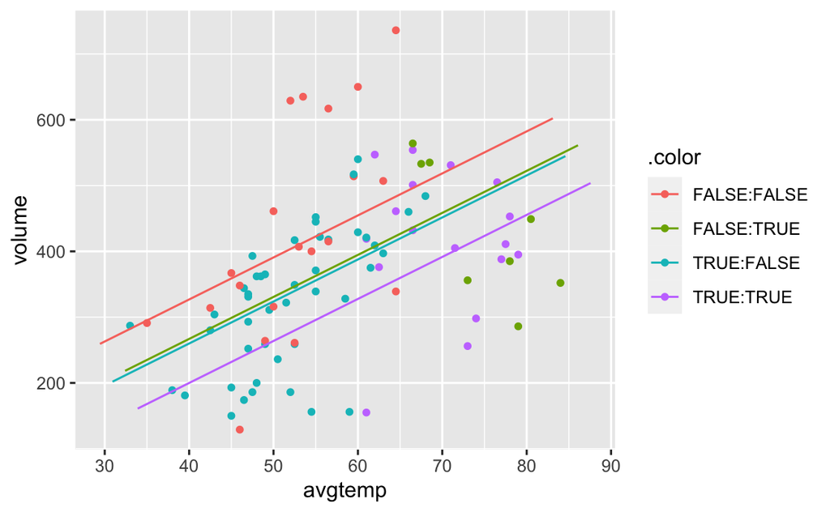

```r
plotModel(model_temp_weekday_summer)
```

summer does not have a statistically significant effect on volume (p = 0.15) also does not reduce standard error of model and barely increases r^2 - summer will not be included in model

###interactions

sometimes there will be a dependancy between independent predictors e.g summer and avg temp

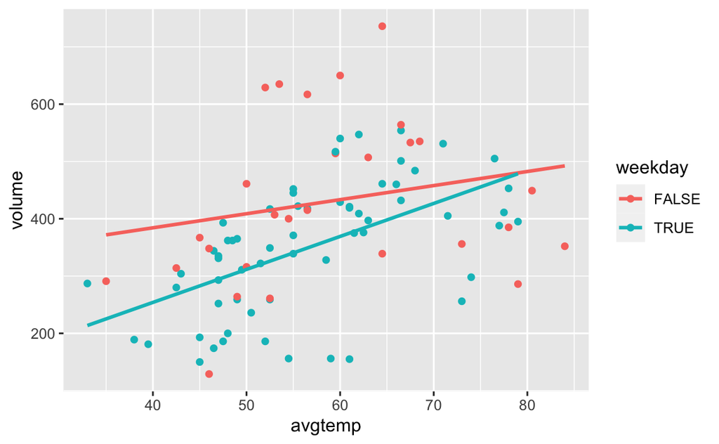

```r
railtrail_trim %>%
  ggplot(aes(x = avgtemp,
             y = volume,
             colour = weekday))+
  geom_point()+
  geom_smooth(method = "lm", se = FALSE)
```

lines of best fit are different for avgtemp vs volume for weekdays and weekends

volume ~ avgtemp + weekday + avgtemp:weekday

the effect on volume of an increase in temeperature depends on whether its a weekday or not

```r
model_temp_weekday_interTW <- lm(volume ~ avgtemp + weekday + avgtemp:weekday, railtrail_trim)

summary(model_temp_weekday_interTW)
```

```
Call:
lm(formula = volume ~ avgtemp + weekday + avgtemp:weekday, data = railtrail_trim)

Residuals:
     Min       1Q   Median       3Q      Max
-269.906  -78.862    2.064   68.190  291.641

Coefficients:
                    Estimate Std. Error t value Pr(>|t|)
(Intercept)          285.887    103.390   2.765  0.00696 **
avgtemp                2.457      1.718   1.431  0.15619
weekdayTRUE         -262.193    128.181  -2.045  0.04386 *
avgtemp:weekdayTRUE    3.300      2.161   1.527  0.13040
---
Signif. codes:  0 ‘***’ 0.001 ‘**’ 0.01 ‘*’ 0.05 ‘.’ 0.1 ‘ ’ 1

Residual standard error: 111 on 86 degrees of freedom
Multiple R-squared:  0.2675,    Adjusted R-squared:  0.2419
F-statistic: 10.47 on 3 and 86 DF,  p-value: 6.115e-06
```

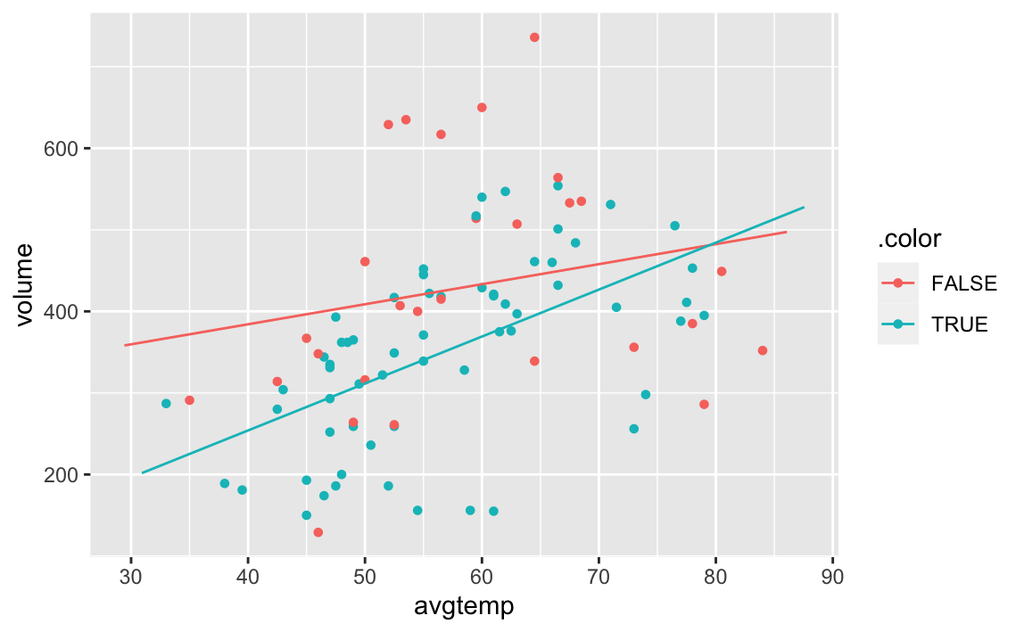

if weekday is TRUE volume = 285 + 2.457 * avgtemp - 262 + 3.3 * avgtemp

if weekday is FALSE volume = 285 + 2.457 * avgtemp

###adding a continuous (cloudcover)